# tutorial

Benjamin Clark

14/04/2021

## Initializing

Everytime you make a new R script you’ll need to be working out of the project directory. To start click project tab in the top-right corner and select “de-expression-igem”. Now to make sure R knows the context for pathing to different files, we need to set the working directory to that of the project. Click on Session -> Set Working Directory -> To Project Directory. Code should run in your console and it should depend on where you dumped your repo within your computer.

Now we need to load up our packages and functions

Moving on!

## Pulling Data from GEO

This is actually very easy. We use our handy GEOquery package and simply give getGEO() the code for the study.

```r
gse <- getGEO("GSE4136", GSEMatrix =TRUE, AnnotGPL=TRUE)[[1]]
#getGEO returns a list in case we have a superseries of studies. In our case i think we are always working with one. This is why we pull the #first element using [[1]]
```

## Exploring the Study

Let’s explore our gse object a bit. Imagine that its a container for the experiment’s metadata (Authors, lab location, etc), probe level metadata (gene names, entrez codes, chromosome location etc) and the matrices for each replicate in the study. These are accessed using a variety of BioBase functions that I’ll get to, for now lets crack open the top level information.

```r
gse$channel_count[[1]]
```

```
[1] "1"
```

The last one tells us how many colours were being used for the array. In this case only one colour was hybridized, meaning that in order to find the difference between treatments, two chips were used between the replicates. There are many cases where two colours are used and I’ll come back to that later.

What does our expression data look like anyways?

```r
head(exprs(gse))
```

```
           GSM94606 GSM94608 GSM94609 GSM94610 GSM94611 GSM94612 GSM94613 GSM94614 GSM94615 GSM94616 GSM94617 GSM94618
1769308_at    0.717    0.848    0.537    0.465    0.480    0.449    1.166    1.153    1.201    1.356    1.313    1.471
1769309_at    0.968    0.940    0.959    1.002    0.989    1.044    0.834    1.205    1.006    1.047    1.027    0.964
1769310_at    0.989    1.023    1.232    0.998    1.242    0.996    0.934    0.841    0.940    0.866    1.218    1.056
1769311_at    0.877    1.129    0.702    0.693    0.838    0.746    1.099    1.124    1.116    1.128    1.053    0.955
1769312_at    0.752    0.746    0.881    0.825    0.795    0.985    1.196    1.226    1.197    1.032    1.061    1.017
1769313_at    0.648    0.672    0.794    0.745    0.959    0.728    1.053    1.151    1.094    1.344    1.039    1.146
```

```r
#for a better look use the View() function
```

This is actually a very large table, owing the fact that each chip has ~10k probes and there a 12 of them!

```r
dim(exprs(gse))
```

```
[1] 10928    12
```

Now lets look at the probe level annotation data

```r
head(fData(gse))
```

|  | ID | Gene title | Gene symbol | Gene ID | UniGene title | UniGene symbol | UniGene ID | Nucleotide Title | GI | GenBank Accession | Platform_CLONEID | Platform_ORF | Platform_SPOTID | Chromosome location | Chromosome annotation | GO:Function | GO:Process | GO:Component | GO:Function ID | GO:Process ID | GO:Component ID |
| --- | --- | --- | --- | --- | --- | --- | --- | --- | --- | --- | --- | --- | --- | --- | --- | --- | --- | --- | --- | --- | --- |
| 1769308_at | 1769308_at | bifunctional hydroxyacyl-CoA dehydrogenase/enoyl-CoA hydratase FOX2 | FOX2 | 853878 | NA | NA | NA | NA | NA | NA | NA | YKR009C | NA | NA | Chromosome XI, NC_001143.9 (454352..457054, complement) | 3-hydroxyacyl-CoA dehydrogenase activity///catalytic activity///enoyl-CoA hydratase activity///isomerase activity///lyase activity///oxidoreductase activity///oxidoreductase activity, acting on the CH… | fatty acid beta-oxidation///fatty acid beta-oxidation///fatty acid metabolic process///lipid metabolic process///metabolic process///oxidation-reduction process | peroxisome///peroxisome | GO:0003857///GO:0003824///GO:0004300///GO:0016853///GO:0016829///GO:0016491///GO:0016616 | GO:0006635///GO:0006635///GO:0006631///GO:0006629///GO:0008152///GO:0055114 | GO:0005777///GO:0005777 |
| 1769309_at | 1769309_at | histone H3 h3.3 | hht3 | 2539804 | NA | NA | NA | NA | NA | NA | NA | SPBC1105.11c | NA | NA | Chromosome II, NC_003423.3 (3528800..3529657, complement) | DNA binding///protein binding | cellular response to DNA damage stimulus///cellular response to DNA damage stimulus///chromatin assembly or disassembly | mating-type region heterochromatin///nuclear nucleosome///nuclear pericentric heterochromatin///nuclear subtelomeric heterochromatin | GO:0003677///GO:0005515 | GO:0006974///GO:0006974///GO:0006333 | GO:0031934///GO:0000788///GO:0031618///GO:1990707 |
| 1769310_at | 1769310_at | notchless-like protein (predicted) | SPCC18.05c | 2539380 | NA | NA | NA | NA | NA | NA | NA | SPCC18.05c | NA | NA | Chromosome III, NC_003421.2 (1962945..1964811, complement) | molecular_function | ribosome biogenesis | nucleolus///nucleus///protein complex | GO:0003674 | GO:0042254 | GO:0005730///GO:0005634///GO:0043234 |
| 1769311_at | 1769311_at | hypothetical protein | YDL157C | 851398 | NA | NA | NA | NA | NA | NA | NA | YDL157C | NA | NA | Chromosome IV, NC_001136.10 (174232..174588, complement) | molecular_function | biological_process | mitochondrion///mitochondrion | GO:0003674 | GO:0008150 | GO:0005739///GO:0005739 |
| 1769312_at | 1769312_at | Pcl6p | PCL6 | 856787 | NA | NA | NA | NA | NA | NA | NA | YER059W | NA | NA | Chromosome V, NC_001137.3 (272624..273886) | cyclin-dependent protein serine/threonine kinase regulator activity///protein kinase binding | carbohydrate metabolic process///glycogen metabolic process///regulation of cyclin-dependent protein serine/threonine kinase activity///regulation of glycogen biosynthetic process///regulation of glyc… | cyclin-dependent protein kinase holoenzyme complex///cytoplasm///nucleus | GO:0016538///GO:0019901 | GO:0005975///GO:0005977///GO:0000079///GO:0005979///GO:0005981 | GO:0000307///GO:0005737///GO:0005634 |
| 1769313_at | 1769313_at | protein kinase PKP2 | PKP2 | 852821 | NA | NA | NA | NA | NA | NA | NA | YGL059W | NA | NA | Chromosome VII, NC_001139.9 (392223..393698) | ATP binding///kinase activity///nucleotide binding///protein kinase activity///pyruvate dehydrogenase (acetyl-transferring) kinase activity///pyruvate dehydrogenase (acetyl-transferring) kinase activi… | carbohydrate metabolic process///carbon utilization///glucose metabolic process///negative regulation of catalytic activity///peptidyl-serine phosphorylation///phosphorylation///protein phosphorylatio… | mitochondrial matrix///mitochondrion///mitochondrion | GO:0005524///GO:0016301///GO:0000166///GO:0004672///GO:0004740///GO:0004740///GO:0016740 | GO:0005975///GO:0015976///GO:0006006///GO:0043086///GO:0018105///GO:0016310///GO:0006468 | GO:0005759///GO:0005739///GO:0005739 |

You can see here every probe (row) has a gene name and extra data associated with it. The functions I have written to extract this information rely on these column names (made by affymetrix or some annotation software). There may be cases that the column names are different or that not all the info we care about is there. If thats the case then we’ll cross that bridge when we get there.

## QA

We need to check if our data is good in the first place and whether we need to normalize it to work out the bumps. First lets check to see if our data has been log transformed:

```r
logcheck(exprs(gse))
```

```
[1] FALSE
```

Looks like it hasn’t, lets fix that quickly.

```r
exprs(gse)[which( exprs(gse) <= 0)] <- NaN
exprs(gse) <- log2(exprs(gse))
```

There are two major ways I assess microarray qualities. The first is a boxplot, simply just seeing if the medians are aligned for each array.

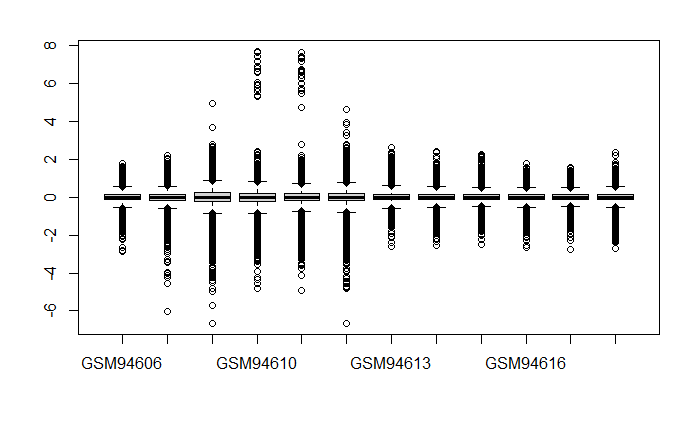

```r
boxplot(exprs(gse))
```

This one looks great! They don’t always look like this though.

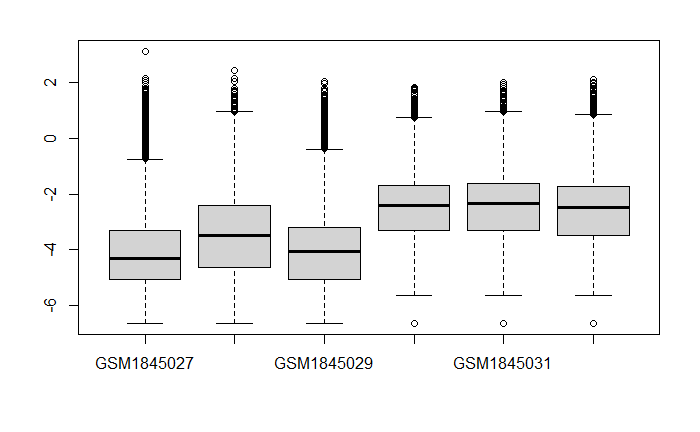

We can see here in the above graph that there’s some bias in the distributions.

The more useful plot (imo) are Density plots. Density plots are (without getting into the theory) a way of showing probability distributions at specific data points across the matrices.

[figure not shown]

```r
plotDensities(exprs(gse))
```

Let’s look at some bad ones.

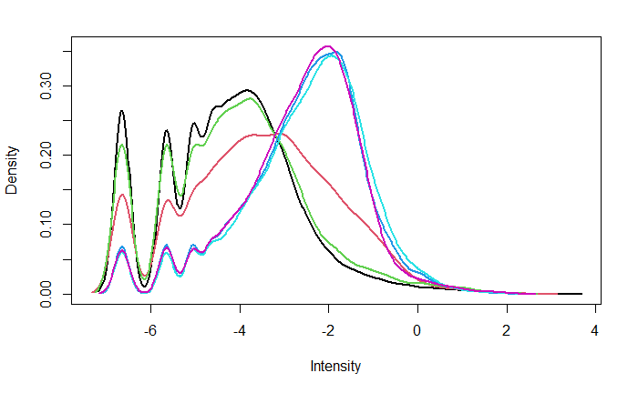

This is the same data used to generate the bad boxplot we saw before. Notice how we found some hidden variation in the red line that we didn’t see before. While this one is clearly all over the place there are more subtle situations.

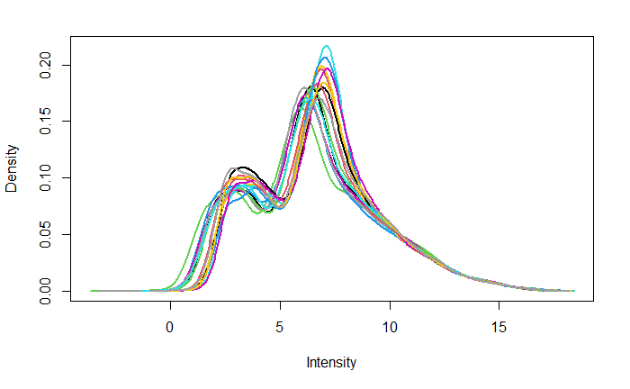

The the first bump is evidence of saturation, a common error with microarrays. This amount is excusable though. There are situations however that saturation will make a study unusable.

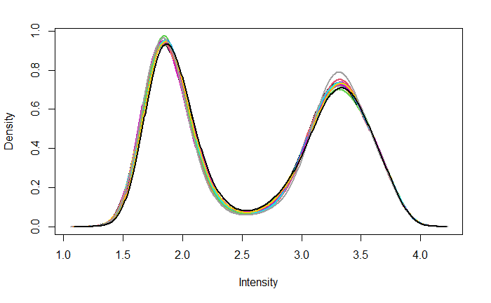

There are plenty of other ways we can look at our data, but for our purposes this is enough.

## Limma

Let’s do some differential expression analysis using Limma. The main goal is to separate the two groups we want on the basis of their treatments and build a design matrix. In the study we were working with before we had RNA extracted at two different time points, 5th and 25th generations. We need to include this in our design and ask Limma to model it.

```r
#format variable names
fvarLabels(gse) <- make.names(fvarLabels(gse))

#This is my levels array, just a short list of descriptors for each sample. Notice how I'm including both "NG" and "MG" for "normal gravity" and #vice versa and the generation number.
levs <- c(rep("NG.5", 3), rep("NG.25",3),rep("MG.5",3), rep("MG.25",3))

#this is a way of recreating a very literal design matrix that we'll use later
targets <- data.frame(cbind(GSE = gse$geo_accession, Target = levs))

#grab the factors from our targets dataframe
f <- factor(targets$Target, levels = unique(levs))

#build a proper design matrix that limma can use
design <- model.matrix(~0+f)

#get rid of the "f"s that R tacks on
colnames(design) <- unique(levs)

#fit the data to a linear model
fit <- lmFit(gse, design)


#Now we need to ask limma to draw contrasts between the groups we want to compare. It is important we get the direction right, with the treated #sample VS the null samples

#5th gen, the names have to match our design names we made before
cont.dif.5 <- makeContrasts(
  Dif5 = MG.5 - NG.5,
  levels = design
)

#fit the contrasts now
contrasts.fit <- contrasts.fit(fit, contrasts = cont.dif.5)

#limma can use naive bayes reduce p values even further by borrowing neighboring values.
fit2 <- eBayes(contrasts.fit, 0.01)

#Here we pull a toptable which will return all our logfc values and (hopefully) annotation data
g.tT5 <- topTable(fit2, adjust.method = "fdr", confint = TRUE, number = Inf)


#Save our data to a flat csv file. NOTE the function pull.output.tT() ONLY works on affymetrix microarrays. You'll have pull the info manually #otherwise. I suggest using dplyr
#Since we are still in the project directory we still need to walk down the repo to the sub directory the R file is in to save it.
gen5name <- "datasets/GSE4136_Scer/GSE4136_5thGen.csv"

#NOT run for this example
#write.table(pull.output.tT(g.tT5), gen5name, row.names = FALSE, sep = ",")



#now for 25th generation
cont.dif.25 <- makeContrasts(
  Dif25 = MG.25 - NG.25,
  levels = design
)

contrasts.fit <- contrasts.fit(fit, contrasts = cont.dif.25)
fit2 <- eBayes(contrasts.fit, 0.01)
g.tT25 <- topTable(fit2, adjust.method = "fdr", confint = TRUE, number = Inf)

gen25name <- "datasets/GSE4136_Scer/GSE4136_25thGen.csv"

#NOT run for this example
#write.table(pull.output.tT(g.tT25), gen25name, row.names = FALSE, sep = ",")
```

That was alot! Let’s just check what ended up with:

```r
head(pull.output.tT(g.tT5))
```

|  | adj.P.Val | P.Value | t | B | logFC | Gene.symbol | Gene.title | Platform_ORF | GO.Function | GO.Function.ID | GO.Process | GO.Process.ID | GO.Component | GO.Component.ID | Chromosome.annotation | ID | Entrez.ID | Standard.Error | Probablity |
| --- | --- | --- | --- | --- | --- | --- | --- | --- | --- | --- | --- | --- | --- | --- | --- | --- | --- | --- | --- |
| 1779946_at | 5.105344e-08 | 9.895574e-12 | -28.02536 | 16.86675 | -3.649774 | AAH1 | adenine deaminase | YNL141W | adenine deaminase activity///adenine deaminase activity///adenine deaminase activity///deaminase activity///hydrolase activity///metal ion binding///zinc ion binding | GO:0000034///GO:0000034///GO:0000034///GO:0019239///GO:0016787///GO:0046872///GO:0008270 | adenine catabolic process///adenine catabolic process///adenine catabolic process///hypoxanthine salvage///hypoxanthine salvage///hypoxanthine salvage///nucleotide metabolic process///purine ribonucle… | GO:0006146///GO:0006146///GO:0006146///GO:0043103///GO:0043103///GO:0043103///GO:0009117///GO:0009168///GO:0043101///GO:0043101 | cytoplasm///cytoplasm///nucleus///nucleus | GO:0005737///GO:0005737///GO:0005634///GO:0005634 | Chromosome XIV, NC_001146.8 (359596..360639) | 1779946_at | 855581 | 0.1459180 | 1.0000000 |
| 1777561_at | 5.105344e-08 | 1.368780e-11 | 27.21487 | 16.60940 | 3.973140 | MPC3 | mitochondrial pyruvate carrier | YGR243W | pyruvate transmembrane transporter activity///pyruvate transmembrane transporter activity///pyruvate transmembrane transporter activity | GO:0050833///GO:0050833///GO:0050833 | mitochondrial pyruvate transmembrane transport///mitochondrial pyruvate transport///mitochondrial pyruvate transport///mitochondrial pyruvate transport///transport | GO:1902361///GO:0006850///GO:0006850///GO:0006850///GO:0006810 | integral component of membrane///membrane///mitochondrial inner membrane///mitochondrial membrane///mitochondrion///mitochondrion | GO:0016021///GO:0016020///GO:0005743///GO:0031966///GO:0005739///GO:0005739 | Chromosome VII, NC_001139.9 (977336..977776) | 1777561_at | 853158 | 0.1635768 | 0.9999999 |
| 1778079_at | 5.105344e-08 | 1.401540e-11 | 27.15668 | 16.59048 | 3.050793 | BTN2 | Btn2p | YGR142W | SNARE binding///SNARE binding///chaperone binding | GO:0000149///GO:0000149///GO:0051087 | amino acid transport///intracellular protein transport///intracellular protein transport///protein folding///protein folding///protein folding///protein localization to nucleus///protein localization … | GO:0006865///GO:0006886///GO:0006886///GO:0006457///GO:0006457///GO:0006457///GO:0034504///GO:0034504///GO:0006885///GO:0006885///GO:0042147 | cytoplasm///cytosol///endosome///late endosome///late endosome///nuclear periphery///nucleus///perinuclear region of cytoplasm | GO:0005737///GO:0005829///GO:0005768///GO:0005770///GO:0005770///GO:0034399///GO:0005634///GO:0048471 | Chromosome VII, NC_001139.9 (772454..773686) | 1778079_at | 853043 | 0.1258723 | 0.9999999 |
| 1770707_at | 3.172809e-07 | 1.161350e-10 | 22.41371 | 14.81934 | 3.978229 | TDA10 | putative ATP-dependent kinase | YGR205W | ATP binding///ATP binding///glycerate kinase activity///kinase activity///nucleotide binding///transferase activity///NOT uridine kinase activity | GO:0005524///GO:0005524///GO:0008887///GO:0016301///GO:0000166///GO:0016740///NOT GO:0004849 | biological_process///phosphorylation///photorespiration///NOT pyrimidine nucleobase metabolic process///NOT pyrimidine nucleoside salvage | GO:0008150///GO:0016310///GO:0009853///NOT GO:0006206///NOT GO:0043097 | cytoplasm///cytoplasm///cytosol///nucleus///nucleus | GO:0005737///GO:0005737///GO:0005829///GO:0005634///GO:0005634 | Chromosome VII, NC_001139.9 (909213..910085) | 1770707_at | 853119 | 0.1988704 | 0.9999996 |
| 1774947_at | 5.146125e-07 | 2.401149e-10 | -20.97684 | 14.17788 | -2.614025 | TOS4 | Tos4p | YLR183C | chromatin binding | GO:0003682 | cellular response to DNA damage stimulus///regulation of gene expression | GO:0006974///GO:0010468 | Rpd3L-Expanded complex///cytoplasm///mitochondrion///nuclear chromatin///nucleus///nucleus | GO:0070210///GO:0005737///GO:0005739///GO:0000790///GO:0005634///GO:0005634 | Chromosome XII, NC_001144.5 (520543..522012, complement) | 1774947_at | 850880 | 0.1396251 | 0.9999993 |
| 1779615_at | 5.146125e-07 | 3.182845e-10 | -20.44340 | 13.92495 | -2.729534 | PHO3 | acid phosphatase PHO3 | YBR092C | acid phosphatase activity///acid phosphatase activity///hydrolase activity///phosphatase activity | GO:0003993///GO:0003993///GO:0016787///GO:0016791 | phosphate-containing compound metabolic process///thiamine-containing compound metabolic process | GO:0006796///GO:0042723 | cell wall-bounded periplasmic space///endoplasmic reticulum | GO:0030287///GO:0005783 | Chromosome II, NC_001134.8 (427698..429101, complement) | 1779615_at | 852389 | 0.1495992 | 0.9999991 |

## Limma 2 Channel Example

A two channel array means that both your null sample and your treated sample are passed over the same chip but hybridized with different colours. Fortunately Limma doesn’t care and the only thing you need to change is the new design matrix. Here’s and example where the researchers swapped the dyes to model possible hybridization bias:

```r
gse3 <- getGEO("GSE50881", GSEMatrix =TRUE, AnnotGPL=TRUE)[[1]]
```

[output not shown]

```r
fvarLabels(gse3) <- make.names(fvarLabels(gse3))

#Limma really wants you to have 'Cy3' and 'Cy5' as column names if you have more than one. These names reference the dyes commonly used.
targets <- data.frame(cbind(GSE = gse$geo_accession, Cy3 = gse3$`growth condition:ch1`, Cy5 = gse3$`growth condition:ch2`))


design <- modelMatrix(targets, ref = "ground-based control condition")
```

```
Found unique target names:
 ground-based control condition spaceflight condition
```

```r
design <- cbind(design, DyeEffect = 1)

fit <- lmFit(gse3,design)
```

```
Partial NA coefficients for 45 probe(s)
```

```r
fit <- eBayes(fit, 0.01)

topTable(fit, coef = "spaceflight condition")
```

|  | ID | SPOT_ID | Block | Column | Row | CGD_Systematic_Name | Description | SEQUENCE | logFC | AveExpr | t | P.Value | adj.P.Val | B |
| --- | --- | --- | --- | --- | --- | --- | --- | --- | --- | --- | --- | --- | --- | --- |
| 15466 | 15466 | orf19.519_519 | 37 | 10 | 17 | orf19.8150 | RRN10 \| orf19.8150 \| IPF8168.2 \| Contig20053:complement(99444..98857)\|weakly similar to rDNA transcriptional activator UAF | TTACTCTCTGATGAAGAAAGTGACTCTAAGGTGAATAATGAGGATGTACAATATGAACACGAAGA | -1.7195384 | -0.06296159 | -10.159029 | 4.116468e-06 | 0.03535705 | 4.249441 |
| 5297 | 5297 | orf19.911_6392 | 13 | 5 | 13 | orf19.8530 | TOM12 \| orf19.8530 \| IPF26413.1 \| Contig20076:259261..260976 \| orf19.8529 \| IPF26466.1 \| Contig20076:254282..259135\|E3 ubiqitin ligase required for G2/M transition | GCATGTAGGTCGTGTATCAAAGCATTGTAACCAAGATAATAAATTACATATCAAGTGGACTATGG | -1.5986964 | 0.62944635 | -9.462563 | 7.281211e-06 | 0.03535705 | 3.835147 |
| 2762 | 2762 | orf19.6953_1839 | 7 | 11 | 12 | orf19.14215 | \| orf19.14215 \| IPF20183.1 \| Contig20259:complement(54335..52419)\|conserved hypothetical protein | CCAAAAAAAGTCGATAATGTCGTTTGGGATAGTTTAGGTGGAATTGGTGTTAATGTCACTGTTAA | -1.1560164 | -0.24198360 | -9.462419 | 7.282094e-06 | 0.03535705 | 3.835057 |
| 1679 | 1679 | empty | 4 | 20 | 20 |  |  |  | -2.4806741 | 1.66953272 | -17.555044 | 7.685325e-07 | 0.01549362 | 3.667717 |
| 2626 | 2626 | orf19.6953_1839 | 7 | 1 | 6 | orf19.14215 | \| orf19.14215 \| IPF20183.1 \| Contig20259:complement(54335..52419)\|conserved hypothetical protein | CCAAAAAAAGTCGATAATGTCGTTTGGGATAGTTTAGGTGGAATTGGTGTTAATGTCACTGTTAA | -1.1864367 | -0.33481329 | -9.083265 | 1.008393e-05 | 0.03535705 | 3.590643 |
| 14938 | 14938 | orf19.6239_855 | 36 | 7 | 12 | orf19.13619 | KIN28 \| orf19.13619 \| IPF15293.1 \| Contig20241:complement(84623..83592)\|serine-threonine kinase, subunit of RNA Pol TFIIK | TCGATGACCCAATTGGATCCAAGTAGAAGATGTGATTCTACACTAGCATTATTACACGATTATTT | 1.0641726 | -0.16417263 | 8.948075 | 1.135599e-05 | 0.03535705 | 3.500052 |
| 8892 | 8892 | orf19.4626_1116 | 22 | 9 | 4 | orf19.12096 | TAP42 \| orf19.12096 \| IPF22598.1 \| Contig20212:120724..121905\|TOR signal transduction pathway \| associates with Pp2ap and Sit4p protein phosphatase catalytic subunits | CGATGGGATGATTGGAAAGATGAAAATCCTAAAGGTGCTGGTAATATGAAAGCTAATATTGGTTA | 1.1499617 | -0.31321171 | 8.860263 | 1.227675e-05 | 0.03535705 | 3.440206 |
| 11865 | 11865 | orf19.6964_214 | 29 | 21 | 5 |  | MRS107 \| \|hypothetical protein | CGATTAAGGTGGATATTTACATAGTAAAAATTGGGGGTTGTCTGTATAGCAACTTTTTGTTAGAC | -1.1961315 | 1.53713151 | -7.867374 | 3.105590e-05 | 0.07128586 | 2.704670 |
| 12137 | 12137 | orf19.6964_214 | 29 | 20 | 18 |  | MRS107 \| \|hypothetical protein | CGATTAAGGTGGATATTTACATAGTAAAAATTGGGGGTTGTCTGTATAGCAACTTTTTGTTAGAC | -0.9731692 | 1.33791918 | -7.842483 | 3.182405e-05 | 0.07128586 | 2.684753 |
| 5161 | 5161 | orf19.911_6392 | 13 | 16 | 6 | orf19.8530 | TOM12 \| orf19.8530 \| IPF26413.1 \| Contig20076:259261..260976 \| orf19.8529 \| IPF26466.1 \| Contig20076:254282..259135\|E3 ubiqitin ligase required for G2/M transition | GCATGTAGGTCGTGTATCAAAGCATTGTAACCAAGATAATAAATTACATATCAAGTGGACTATGG | -1.2925296 | 0.80152964 | -7.517259 | 4.404045e-05 | 0.08155747 | 2.417391 |

The last thing we need to do is print out some metadata. There are two files for each comparison we made, a text file which dumps all the study info and another csv file which describes the comparisons we made. Big warning on this one: the function I made is not very stable. This is probably because I over-engineered it (oops). The idea is that you can give it all the info and it makes all those files at once. If it whines it probably means you need to twist the inputs into something it likes.

```r
#one general name for all the meta files
metaName <- "datasets/GSE4136_Scer/GSE4136_meta"


strain <- "BY4743"


#one label for each comparison we made
labels <- c("5thGen", "25thGen")

#microgravity_type needs to be derived from M.TYPE, design is the output from our model matrix, contrasts is a LIST of separate contrasts made from #make.Contrasts()

extractMetaData(gse = gse, metaLabels = labels,
                microgravity_type = M.TYPE$HARV, design = design,
                contrasts = list(cont.dif.5, cont.dif.25), strain = strain,
                filename = metaName)
```

Now push a new branch using git and thats it!

```r
git checkout -b GSE4136
git add --all
git commit -m new study
git push -u origin GSE4136
```